# BACSAL_new

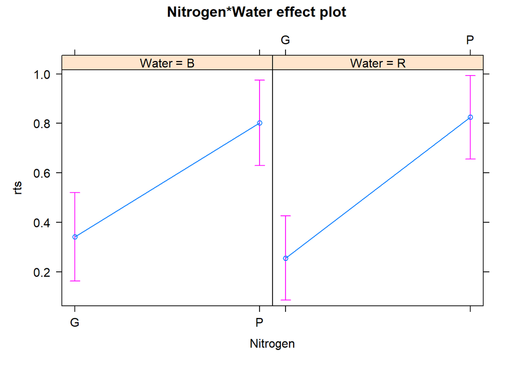

```r
#plotting N-Water interaction effects
library(effects)
library(sjPlot)
eff.p1 <- effect("Nitrogen*Water", hmod1, KR=T)
plot(eff.p1)
```

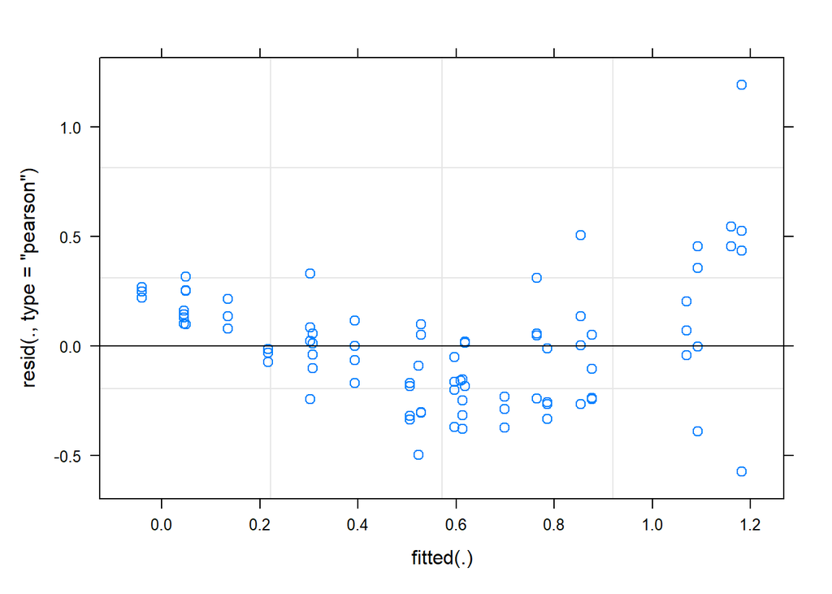

```r
plot(hmod1) #plotting residuals; output is NOT very random
```

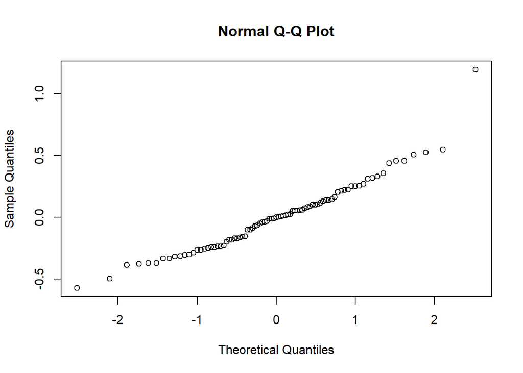

```r
#look at non-normal residuals; QQ-plot
qqnorm(resid(hmod1)) #pretty good! one outlier (check on BOYD-13, run with AND without)-if they aren't too different, it's ok! try removing it and seeing
```

Building a linear regression model for root-to-shoot ratio

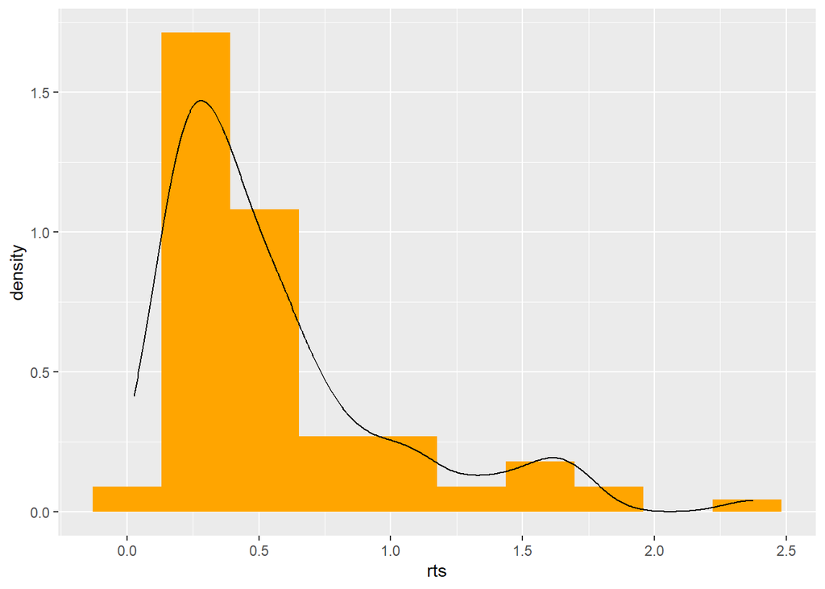

```r
#Distribution Check
bsdata_complete %>%
  ggplot() +
    aes(rts) +
    geom_histogram(na.rm = T,
                   aes(y = after_stat(density)), fill = "orange",
                   bins = 10) +
    geom_density(na.rm = T)
```

```r
#Not very normal - has heavy outliers (from BOYD Low N group)
#what matters is residuals are normally dist, NOT the data itself

#Using lmer package, allows for mixed effects model
mod_rts <- lmer(rts ~ Water*Nitrogen + AIKoppen + (1 | Origin) + (1 | Parent:Origin), data = bsdata_complete)
#Origin and Parent:Origin are random effects, not what we're looking at
#Note: Adding in 'Sex' Variable produces a singular fit error, may be overleveraged (fewer degrees of freedom)

summary(mod_rts)
```

```
## Linear mixed model fit by REML. t-tests use Satterthwaite's method [
## lmerModLmerTest]
## Formula: rts ~ Water * Nitrogen + AIKoppen + (1 | Origin) + (1 | Parent:Origin)
##    Data: bsdata_complete
##
## REML criterion at convergence: 50.3
##
## Scaled residuals:
##     Min      1Q  Median      3Q     Max
## -1.8495 -0.6850 -0.0298  0.5399  4.2035
##
## Random effects:
##  Groups        Name        Variance  Std.Dev.
##  Parent:Origin (Intercept) 0.0007458 0.02731
##  Origin        (Intercept) 0.0021095 0.04593
##  Residual                  0.0859904 0.29324
## Number of obs: 85, groups:  Parent:Origin, 12; Origin, 3
##
## Fixed effects:
##                  Estimate Std. Error       df t value Pr(>|t|)
## (Intercept)       0.81209    0.11386  2.53115   7.132  0.00973 **
## WaterR           -0.08480    0.09194 71.45181  -0.922  0.35945
## NitrogenP         0.45709    0.09290 72.10342   4.920 5.28e-06 ***
## AIKoppen         -0.09082    0.01681  1.14995  -5.403  0.09343 .
## WaterR:NitrogenP  0.10566    0.12767 71.25745   0.828  0.41066
## ---
## Signif. codes:  0 '***' 0.001 '**' 0.01 '*' 0.05 '.' 0.1 ' ' 1
##
## Correlation of Fixed Effects:
##             (Intr) WaterR NtrgnP AIKppn
## WaterR      -0.452
## NitrogenP   -0.433  0.531
## AIKoppen    -0.767  0.023  0.006
## WtrR:NtrgnP  0.289 -0.718 -0.727  0.029
```

```r
anova(mod_rts)
```

```
## Type III Analysis of Variance Table with Satterthwaite's method
##                Sum Sq Mean Sq NumDF  DenDF F value    Pr(>F)
## Water          0.0214  0.0214     1 71.372  0.2493   0.61912
## Nitrogen       5.4785  5.4785     1 72.131 63.7106 1.639e-11 ***
## AIKoppen       2.5105  2.5105     1  1.150 29.1951   0.09343 .
## Water:Nitrogen 0.0589  0.0589     1 71.257  0.6849   0.41066
## ---
## Signif. codes:  0 '***' 0.001 '**' 0.01 '*' 0.05 '.' 0.1 ' ' 1
```

```r
step_result <- step(mod_rts)

final_model <- get_model(step_result)
final_model
```

```
##
## Call:
## lm(formula = rts ~ Nitrogen + AIKoppen, data = bsdata_complete)
##
## Coefficients:
## (Intercept)    NitrogenP     AIKoppen
##     0.76052      0.51433     -0.09006
```

```r
summary(final_model)
```

```
##
## Call:
## lm(formula = rts ~ Nitrogen + AIKoppen, data = bsdata_complete)
##
## Residuals:
##      Min       1Q   Median       3Q      Max
## -0.57325 -0.20414 -0.02248  0.15747  1.26305
##
## Coefficients:
##             Estimate Std. Error t value Pr(>|t|)
## (Intercept)  0.76052    0.08185   9.292 1.89e-14 ***
## NitrogenP    0.51433    0.06380   8.061 5.29e-12 ***
## AIKoppen    -0.09006    0.01285  -7.008 6.20e-10 ***
## ---
## Signif. codes:  0 '***' 0.001 '**' 0.01 '*' 0.05 '.' 0.1 ' ' 1
##
## Residual standard error: 0.2936 on 82 degrees of freedom
##   (10 observations deleted due to missingness)
## Multiple R-squared:  0.5936, Adjusted R-squared:  0.5836
## F-statistic: 59.88 on 2 and 82 DF,  p-value: < 2.2e-16
```

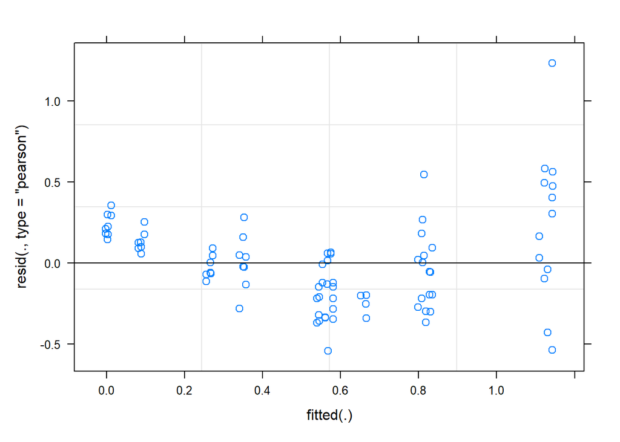

```r
#formula = rts ~ Nitrogen + AIKoppen
plot(mod_rts)
```

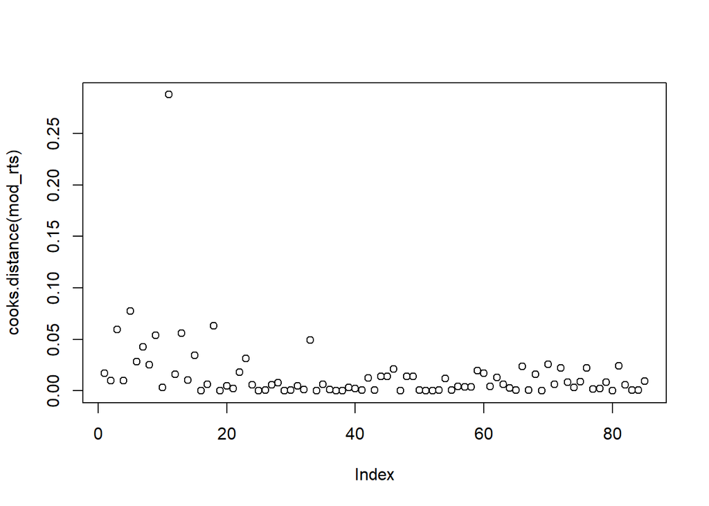

```r
plot(cooks.distance(mod_rts))
```

```r
summary(final_model)$r.squared
```

```
## [1] 0.5935616
```

Root-shoot ratio, by AIKoppen

[figure not shown]

```r
bsdata_complete %>%
  ggplot() +
    aes(x = AIKoppen, y = rts, fill = Origin) +
    geom_boxplot(na.rm = T) + #removes missing values
    ggtitle("Root-shoot ratio") +
    labs(y = "Root-to-Shoot Ratio",
         x = "Koppen Aridity Index") +
    scale_fill_discrete(labels = c("BOYD", "ELFR", "COAL"))
```

```r
#Create temp df for stats tests
origin_rts <- bsdata_complete$rts

#One-Way ANOVA to determine statistical significance + Tukey multiple pairwise-comparison
# rts.aov <- aov(rts ~ Origin, data = origin_rts)
# summary(rts.aov)
# TukeyHSD(rts.aov)
#Note: From Tukey test, ELFR & COAL are NOT statistically significant from each other
```

Fine:Coarse Root Ratio -need to do some digging in McCormack 2015 Note: McCormack et al. 2015 uses arbitrary 2 mm as cutoff for fine:coarse roots ratio and questions this cutoff. Blume-Werry et al. 2017 uses log transformed fine/coarse root ratio (dimensionless).

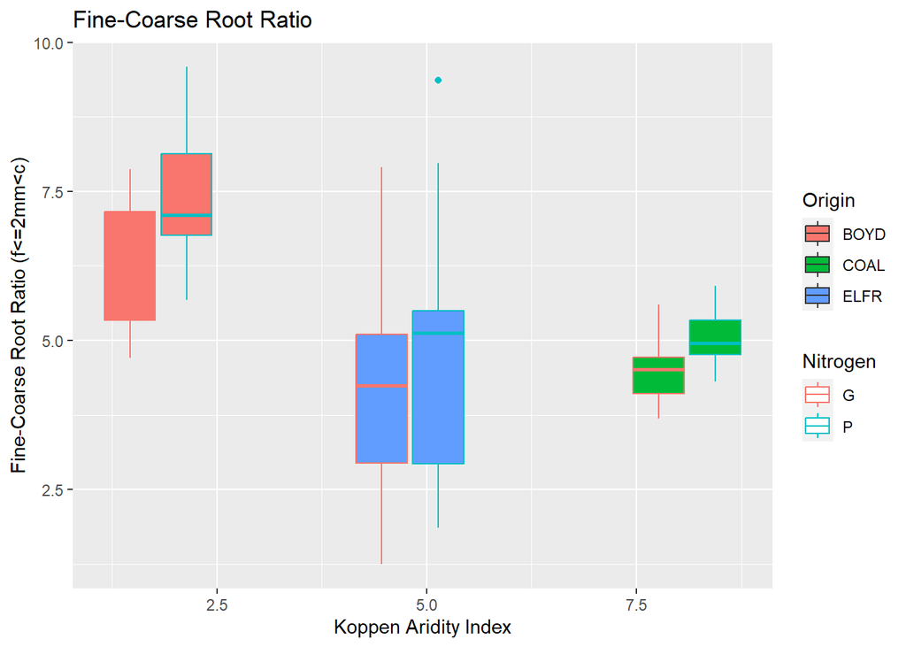

```r
bsdata_complete %>%
  mutate(froots = (L01 + L02 + L03 + L04)) %>%
  mutate(croots = (L05 + L06 + L07 + L08 + L09 + L10)) %>%
  mutate(fcr = froots/croots) %>%
  ggplot() +
    aes(x = AIKoppen, y = log(fcr), fill = Origin, color = Nitrogen) +
    geom_boxplot(na.rm = T) +
      ggtitle("Fine-Coarse Root Ratio") +
        labs(y = "Fine-Coarse Root Ratio (f<=2mm<c)",
         x = "Koppen Aridity Index")
```

According to Funk et al. 2017, a soft trait like SLA “can explain a large portion of the variation in RGR across a large range of herbaceous and woody plant species”. can SRA (specific root area) do the same for root volume?

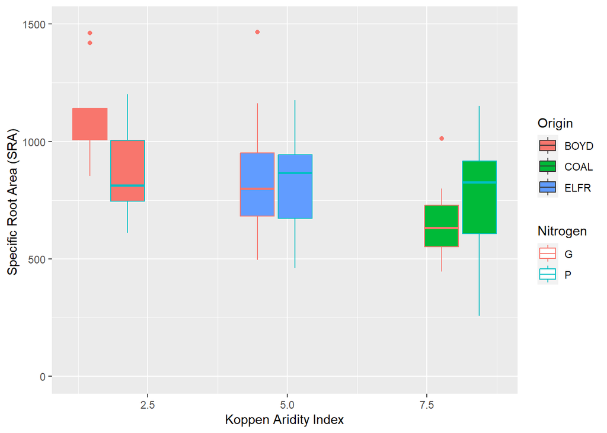

```r
#Specific Root Area by AIKoppen
bsdata_complete %>%
  ggplot() +
    aes(x = AIKoppen, y = sra, fill = Origin, color= Nitrogen) +
    geom_boxplot(na.rm = T) +
    scale_y_continuous(limits = c(0,1500)) +
    labs(y = "Specific Root Area (SRA) ",
         x = "Koppen Aridity Index")
```

```r
#Create temp df for stats tests
origin_sra <- bsdata %>%
  mutate(sra = SurfAreacm2 / RootMassg)

#One-Way ANOVA to determine statistical significance + Tukey multiple pairwise-comparison
sra.aov <- aov(sra ~ Origin, data = origin_sra)
summary(sra.aov)
```

```
##             Df    Sum Sq Mean Sq F value Pr(>F)
## Origin       2   7328726 3664363   2.334  0.104
## Residuals   74 116162970 1569770
## 18 observations deleted due to missingness
```

```r
TukeyHSD(sra.aov)
```

```
##   Tukey multiple comparisons of means
##     95% family-wise confidence level
##
## Fit: aov(formula = sra ~ Origin, data = origin_sra)
##
## $Origin
##                diff       lwr      upr     p adj
## COAL-BOYD -740.6388 -1634.289 153.0115 0.1237356
## ELFR-BOYD -627.6704 -1457.611 202.2704 0.1737469
## ELFR-COAL  112.9683  -706.211 932.1477 0.9418428
```

```r
#Note: None of the SRA's are significantly different, ELFR & COAL are very aligned
```

SRA vs. KWRGR

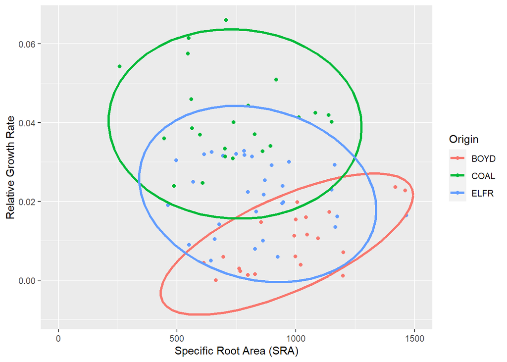

```r
#Specific Root Area vs KW RGR
bsdata_complete %>%
  ggplot() +
    aes(x = sra, y = kwrgr, color = Origin) +
    geom_point(na.rm = T) +
    scale_x_continuous(limits = c(0,1500)) +
    stat_ellipse(na.rm = T,
                 lwd = 1.2) +
    labs(y = "Relative Growth Rate",
         x = "Specific Root Area (SRA)")
```

```r
#Meaning: 3 sites have similar SRA distribution, but BOYD have slower growth rate based on similar SRA, COAL has highest
#run stats on this (BOYD has some slope)
```

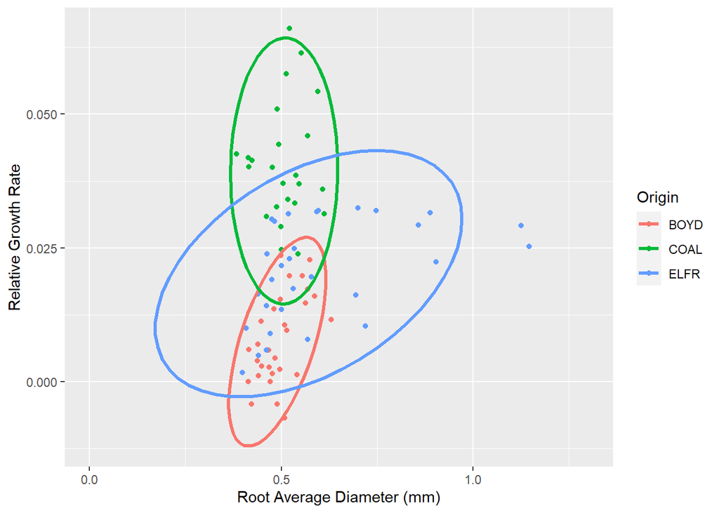

```r
#RGR vs. root diameter
bsdata_complete %>%
  ggplot() +
    aes(x = AvgDiammm, y = kwrgr, color = Origin) +
    geom_jitter(na.rm = T) +
    scale_x_continuous(limits = c(0, 1.3)) +
    stat_ellipse(na.rm = T,
                 lwd = 1.2) +
    labs(y = "Relative Growth Rate",
         x = "Root Average Diameter (mm)")
```

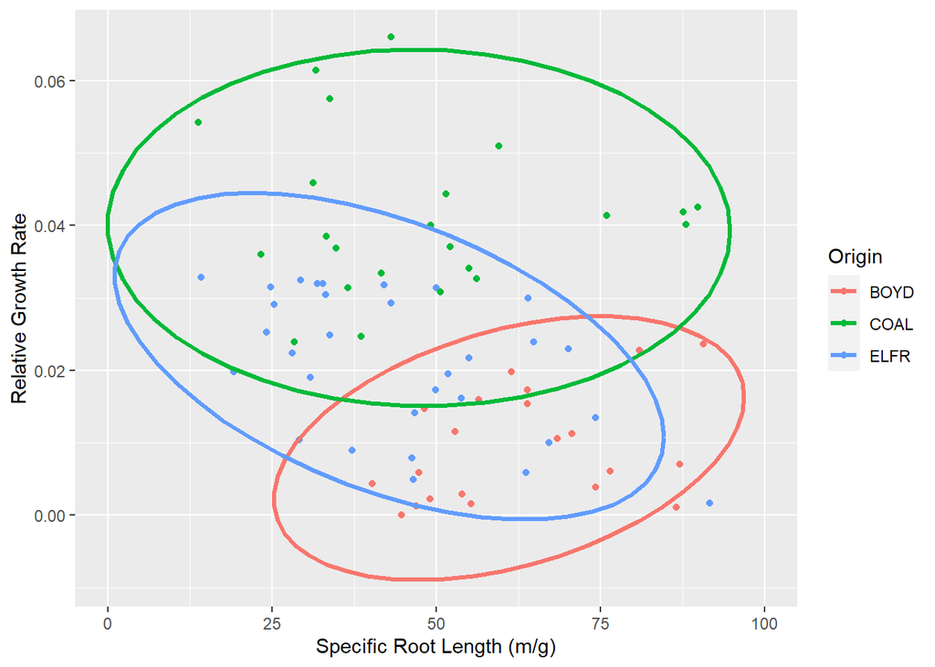

```r
#KWRGR vs. Specific Root Length
bsdata_complete %>%
  ggplot() +
    aes(x = srl, y = kwrgr, color = Origin) +
    geom_point(na.rm = T) +
    scale_x_continuous(limits = c(0,100)) +
    stat_ellipse(na.rm = T,
                 lwd = 1.2) +
    labs(y = "Relative Growth Rate",
         x = "Specific Root Length (m/g)")
```

```r
#High SRL signals more 'exploratory' growth patterns. In BOYD, a high SRL, more exploratory strategy is associated with higher RGR (performance), in ELFR, a low SRL more "conservative" root development is associated with higher RGR/performance. COAL has no clear relationship.
```

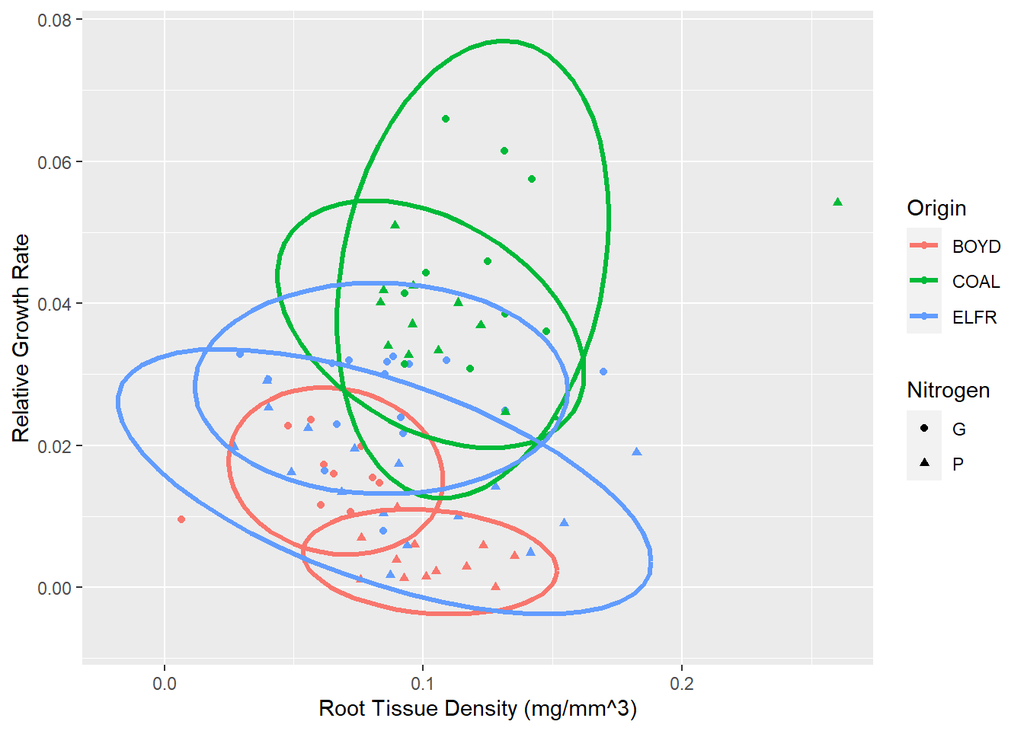

```r
#KWrgr vs. RTD
bsdata_complete %>%
  ggplot() +
    aes(x = rtd, y = kwrgr, color = Origin, shape = Nitrogen) +
    geom_point(na.rm = T) +
    stat_ellipse(na.rm = T,
                 lwd = 1.2) +
    labs(y = "Relative Growth Rate",
         x = "Root Tissue Density (mg/mm^3)")
```

```r
#
```

Root-to-Shoot Ratio vs. kwrgr

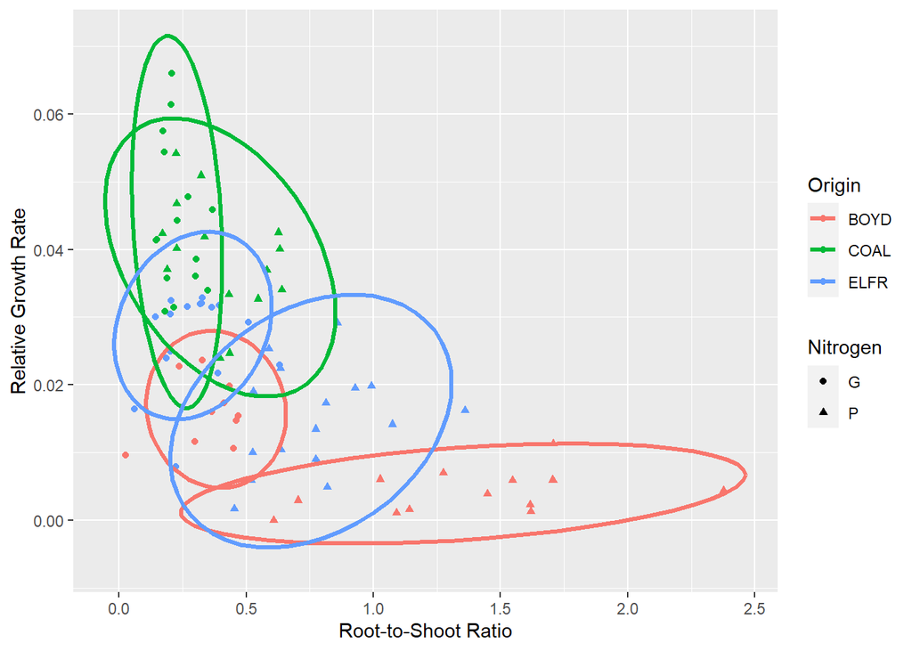

```r
bsdata_complete %>%
  ggplot() +
      aes(x = rts, y = kwrgr, color = Origin, shape = Nitrogen) +
      geom_point(na.rm = T) +
      stat_ellipse(na.rm = T,
                   lwd = 1.2) +
      labs(y = "Relative Growth Rate",
         x = "Root-to-Shoot Ratio")
```

```r
#Low N has a big effect on rts, but rts has little to no effect on RGR
#most extreme diff in BOYD, COAL has most similar rts and rgr between treatments
```

After D-Lab consultation, 2/9/23

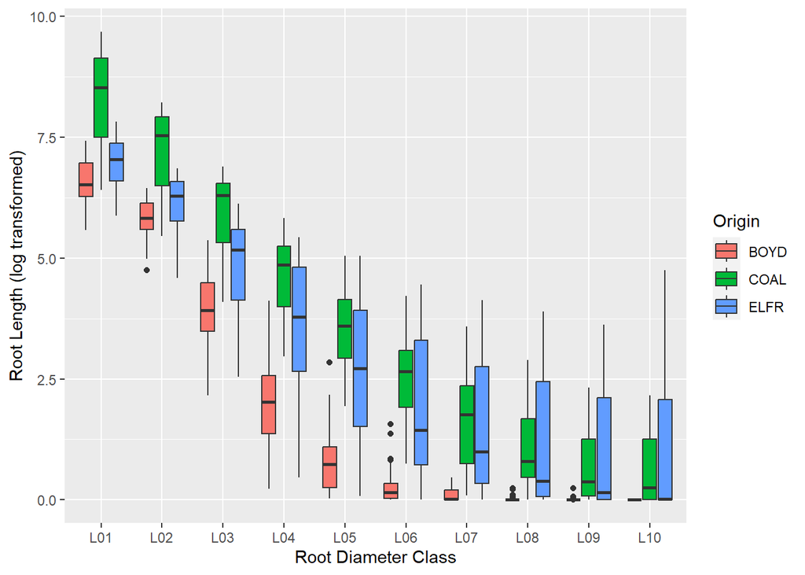

```r
bsdatacat <- bsdata %>%
  pivot_longer(L01:L10, names_to = 'Lcategory', values_to = 'LengthCat');

#Non-normalized
bsdatacat %>%
    ggplot() +
    aes(x = Lcategory, y = log(LengthCat+1), fill = Origin) +
    geom_boxplot(na.rm = T) +##is this counting zeroes?
    labs(y = "Root Length (log transformed)",
         x = "Root Diameter Class")
```

```r
#reorder to be by Aridity (BOYD>ELFR>COAL)
# # Box-Cox plot might be helpful!
```

Models, PCA, and MANOVA

PCA (Principal Component Analysis) - Using PRComp http://www.sthda.com/english/articles/31-principal-component-methods-in-r-practical-guide/118-principal-component-analysis-in-r-prcomp-vs-princomp/#compute-pca-in-r-using-prcomp

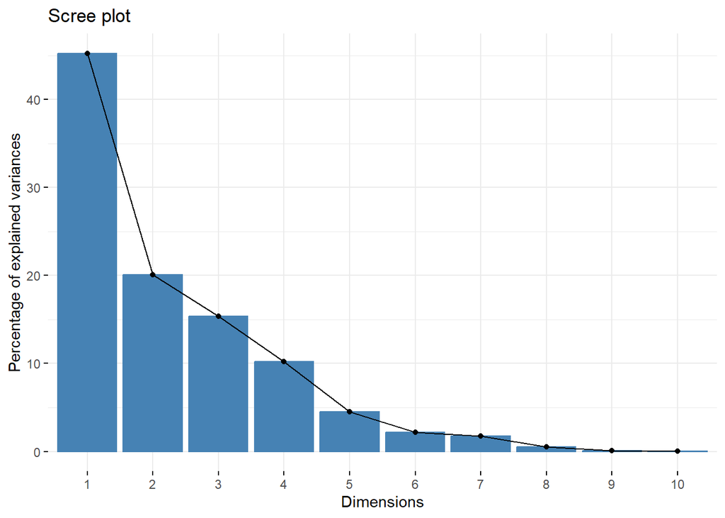

```r
Origin <- bsdata_complete$Origin

#Select relevant root variables
Root_data <- bsdata_complete %>%
  select(Lengthcm, RootMassg, RootVolcm3, SurfAreacm2, ShootMassg,
         AvgDiammm, rts, srl, sra, kwrgr, rtd)

#cor(Root_data, use = 'complete.obs') #checking each trait's correlation

Root_PCA <- prcomp(na.omit(Root_data), scale = T)
#scale = T is if they have different units, and na.omit ignores NA values

fviz_eig(Root_PCA)
```

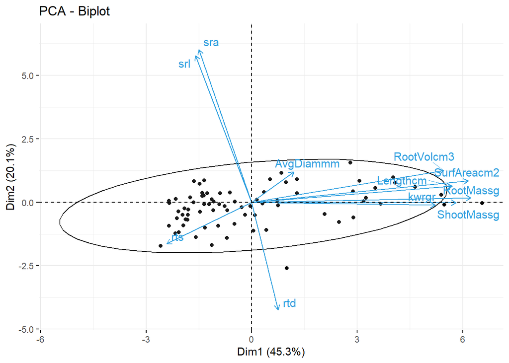

```r
fviz_pca_biplot(Root_PCA,
                repel = T, #Avoid text overlapping
                col.ind = "black", # Individuals
                geom = "point",
                alpha.ind = 1, #turns individuals invisible
                addEllipses = T,
                col.var = "#2E9FDF" # Variables color
                ) +
  ylim(-4.5,6.5)
```

```r
var <- get_pca_var(Root_PCA)
var$contrib
```

```
##                  Dim.1        Dim.2       Dim.3       Dim.4      Dim.5
## Lengthcm    15.2660303 4.333933e-01  2.07853616 11.33896548  7.6577772
## RootMassg   18.2516978 3.088356e-02  0.10514144  3.00541806  1.6369240
## RootVolcm3  14.0151876 1.652857e+00 13.86628081  0.42655501  2.0209980
## SurfAreacm2 17.8108462 7.507883e-01  0.03807188  6.79163950  2.0307408
## ShootMassg  15.8731461 2.036234e-04  3.00668970  1.04594269  2.9697328
## AvgDiammm    0.6831817 1.519522e+00 44.33307825  8.32772977 16.2116552
## rts          2.7524774 2.804879e+00  5.23330164 52.99127284 12.1778699
## srl          1.1952860 3.542224e+01  7.16328326  0.90733455  4.8646720
## sra          1.0657845 3.829875e+01  3.42500535  0.21834513  7.6539280
## kwrgr       12.8214186 1.183356e-02  2.07477855 14.87933194  0.9965495
## rtd          0.2649438 1.907465e+01 18.67583296  0.06746503 41.7791526
##                    Dim.6      Dim.7        Dim.8        Dim.9       Dim.10
## Lengthcm    4.165602e-01  8.4378370 2.027853e+01 11.896223316 12.486404121
## RootMassg   4.097390e+00  2.2022829 5.882926e+01  6.389170641  5.328015664
## RootVolcm3  3.250418e+00  0.9365170 2.755206e-01 55.835253348  0.607054969
## SurfAreacm2 1.065492e+00  3.0498344 3.788542e-01  0.060506586 38.356571653
## ShootMassg  3.036004e+00 62.6841143 1.122689e+01  0.016169733  0.140519251
## AvgDiammm   1.015427e+00  0.7415395 4.000298e+00 20.724308612  0.614984132
## rts         2.383928e+01  0.1912698 3.234951e-05  0.007660998  0.001854003
## srl         3.180399e-03  0.1912997 5.881844e-01  2.521569045 20.777993506
## sra         8.922073e-04  0.2036039 2.963034e-01  2.294912458 21.355934003
## kwrgr       5.244112e+01 14.6737892 1.858321e+00  0.172835486  0.069679149
## rtd         1.083423e+01  6.6879123 2.267811e+00  0.081389776  0.260989550
##                   Dim.11
## Lengthcm    9.709741e+00
## RootMassg   1.238200e-01
## RootVolcm3  7.113357e+00
## SurfAreacm2 2.966665e+01
## ShootMassg  5.909943e-04
## AvgDiammm   1.828276e+00
## rts         9.749451e-05
## srl         2.636495e+01
## sra         2.518655e+01
## kwrgr       3.392465e-04
## rtd         5.625603e-03
```

```r
#?fviz_pca_biplot #help
#dim1 is the 'new' set of variables created. Variables are SO highly correlated, PCA collapses them into ONE variable.
#https://setosa.io/ev/principal-component-analysis/
#note: this looks messy. Could we clean it up?
#from meeting w/ Anusha, 3/10/23 - arrows pointing in same direction are 1.) correlated with each other and 2.) contributing strongly (length of arrow) to dimension 1
#PCA works with colinearity, summarizes what's important into new variables - "What's contributing the most to the variance".
#Look at clustered variables (dim1 = productivity?)
```

LME4 Analysis & Model Building Length

```r
#Building the model
mod_length <- lmer(Lengthcm ~ Origin + Water*Nitrogen + (1 | Parent:Origin), data = bsdata_complete)
#parents form groups within larger groups (Origin)

#summary(mod)
mod_aov <-anova(mod_length)
#mod_aov

# ## Inspect the contrast matrix for the Type III test of Product:
# show_tests(mod_aov)$Origin
# ## Anova-like table of random-effect terms using likelihood ratio tests:
# ranova(mod)
#
# ## F-tests of 'single term deletions' for all marginal terms:
# drop1(mod)

## backward elimination of non-significant effects:
step_result <- step(mod_length)
# step_result

final_model <- get_model(step_result)
final_model
```

```
## Linear mixed model fit by REML ['lmerModLmerTest']
## Formula: Lengthcm ~ Origin + (1 | Parent:Origin)
##    Data: bsdata_complete
## REML criterion at convergence: 1566.361
## Random effects:
##  Groups        Name        Std.Dev.
##  Parent:Origin (Intercept) 2514
##  Residual                  2552
## Number of obs: 86, groups:  Parent:Origin, 12
## Fixed Effects:
## (Intercept)   OriginCOAL   OriginELFR
##      1249.0       7001.9        811.4
```

```r
#Length Model: Lengthcm ~ Origin + (1 | Parent:Origin)

#From my (limited) understanding of the output, only Origin is having a stat signif effect on causing the variation in the model
```

Root-to-Shoot Ratio

```r
mod_rts <- lmer(rts ~ (1|Origin) + Water*Nitrogen + (1 | Sex) + (1 | Parent:Origin), data = bsdata_complete)
```

```
## boundary (singular) fit: see help('isSingular')
```

```r
summary(mod_rts)
```

```
## Linear mixed model fit by REML. t-tests use Satterthwaite's method [
## lmerModLmerTest]
## Formula:
## rts ~ (1 | Origin) + Water * Nitrogen + (1 | Sex) + (1 | Parent:Origin)
##    Data: bsdata_complete
##
## REML criterion at convergence: 49.1
##
## Scaled residuals:
##     Min      1Q  Median      3Q     Max
## -2.0130 -0.7238  0.0540  0.4713  4.0961
##
## Random effects:
##  Groups        Name        Variance Std.Dev.
##  Parent:Origin (Intercept) 0.000000 0.00000
##  Origin        (Intercept) 0.079674 0.28227
##  Sex           (Intercept) 0.005619 0.07496
##  Residual                  0.083675 0.28927
## Number of obs: 85, groups:  Parent:Origin, 12; Origin, 3; Sex, 2
##
## Fixed effects:
##                  Estimate Std. Error       df t value Pr(>|t|)
## (Intercept)       0.36665    0.18399  2.90028   1.993    0.143
## WaterR           -0.08801    0.09072 78.05310  -0.970    0.335
## NitrogenP         0.45950    0.09167 78.08718   5.013 3.28e-06 ***
## WaterR:NitrogenP  0.11010    0.12592 78.04653   0.874    0.385
## ---
## Signif. codes:  0 '***' 0.001 '**' 0.01 '*' 0.05 '.' 0.1 ' ' 1
##
## Correlation of Fixed Effects:
##             (Intr) WaterR NtrgnP
## WaterR      -0.266
## NitrogenP   -0.263  0.531
## WtrR:NtrgnP  0.189 -0.718 -0.726
## optimizer (nloptwrap) convergence code: 0 (OK)
## boundary (singular) fit: see help('isSingular')
```

```r
mod_aov <-anova(mod_rts)

step_result <- step(mod_rts)
```

```
## boundary (singular) fit: see help('isSingular')
```

```r
final_model <- get_model(step_result)
final_model
```

```
## Linear mixed model fit by REML ['lmerModLmerTest']
## Formula: rts ~ Nitrogen + (1 | Origin)
##    Data: bsdata_complete
## REML criterion at convergence: 45.5443
## Random effects:
##  Groups   Name        Std.Dev.
##  Origin   (Intercept) 0.2864
##  Residual             0.2924
## Number of obs: 85, groups:  Origin, 3
## Fixed Effects:
## (Intercept)    NitrogenP
##      0.3232       0.5126
```

```r
#formula = rts ~ Origin + Nitrogen
```

RGR

```r
mod_rgr <- lmer(kwrgr ~ (1|Origin) + Water*Nitrogen + (1 | Sex) + (1 | Parent:Origin), data = bsdata_complete)
```

```
## boundary (singular) fit: see help('isSingular')
```

```r
summary(mod_rgr)
```

```
## Linear mixed model fit by REML. t-tests use Satterthwaite's method [
## lmerModLmerTest]
## Formula:
## kwrgr ~ (1 | Origin) + Water * Nitrogen + (1 | Sex) + (1 | Parent:Origin)
##    Data: bsdata_complete
##
## REML criterion at convergence: -619.5
##
## Scaled residuals:
##      Min       1Q   Median       3Q      Max
## -2.68690 -0.51851  0.04645  0.50182  1.81601
##
## Random effects:
##  Groups        Name        Variance  Std.Dev.
##  Parent:Origin (Intercept) 3.505e-05 5.921e-03
##  Origin        (Intercept) 2.585e-04 1.608e-02
##  Sex           (Intercept) 3.809e-14 1.952e-07
##  Residual                  3.739e-05 6.115e-03
## Number of obs: 94, groups:  Parent:Origin, 12; Origin, 3; Sex, 2
##
## Fixed effects:
##                   Estimate Std. Error        df t value Pr(>|t|)
## (Intercept)       0.025533   0.009525  2.055345   2.681  0.11228
## WaterR            0.004587   0.001808 79.160933   2.537  0.01313 *
## NitrogenP        -0.006044   0.001808 79.160933  -3.343  0.00127 **
## WaterR:NitrogenP -0.005877   0.002527 79.081222  -2.325  0.02261 *
## ---
## Signif. codes:  0 '***' 0.001 '**' 0.01 '*' 0.05 '.' 0.1 ' ' 1
##
## Correlation of Fixed Effects:
##             (Intr) WaterR NtrgnP
## WaterR      -0.095
## NitrogenP   -0.095  0.500
## WtrR:NtrgnP  0.068 -0.714 -0.714
## optimizer (nloptwrap) convergence code: 0 (OK)
## boundary (singular) fit: see help('isSingular')
```

```r
mod_aov <-anova(mod_rgr)

step_result <- step(mod_rgr)
```

```
## boundary (singular) fit: see help('isSingular')
```

```r
final_model <- get_model(step_result)
final_model
```

```
## Linear mixed model fit by REML ['lmerModLmerTest']
## Formula: kwrgr ~ Water + Nitrogen + (1 | Origin) + (1 | Parent:Origin) +
##     Water:Nitrogen
##    Data: bsdata_complete
## REML criterion at convergence: -619.542
## Random effects:
##  Groups        Name        Std.Dev.
##  Parent:Origin (Intercept) 0.005920
##  Origin        (Intercept) 0.016080
##  Residual                  0.006115
## Number of obs: 94, groups:  Parent:Origin, 12; Origin, 3
## Fixed Effects:
##      (Intercept)            WaterR         NitrogenP  WaterR:NitrogenP
##         0.025533          0.004587         -0.006044         -0.005877
```

```r
#formula = kwrgr ~ Origin + Water + Nitrogen + (1 | Parent:Origin) + Water:Nitrogen
```

SRL

```r
mod_srl <- lmer(srl ~ Origin + Water*Nitrogen + (1 | Sex) + (1 | Parent:Origin), data = bsdata_complete)

summary(mod_srl)
```

```
## Linear mixed model fit by REML. t-tests use Satterthwaite's method [
## lmerModLmerTest]
## Formula: srl ~ Origin + Water * Nitrogen + (1 | Sex) + (1 | Parent:Origin)
##    Data: bsdata_complete
##
## REML criterion at convergence: 838
##
## Scaled residuals:
##     Min      1Q  Median      3Q     Max
## -0.8541 -0.3254 -0.1738  0.1696  7.7648
##
## Random effects:
##  Groups        Name        Variance Std.Dev.
##  Parent:Origin (Intercept)   29.42   5.424
##  Sex           (Intercept)  455.14  21.334
##  Residual                  6005.27  77.494
## Number of obs: 77, groups:  Parent:Origin, 12; Sex, 2
##
## Fixed effects:
##                  Estimate Std. Error      df t value Pr(>|t|)
## (Intercept)        91.223     28.827   6.744   3.165   0.0166 *
## OriginCOAL        -47.974     23.560   7.858  -2.036   0.0768 .
## OriginELFR        -49.085     21.935   5.928  -2.238   0.0671 .
## WaterR             24.087     26.075  64.423   0.924   0.3591
## NitrogenP          -1.819     26.093  65.166  -0.070   0.9446
## WaterR:NitrogenP  -27.863     35.604  62.922  -0.783   0.4368
## ---
## Signif. codes:  0 '***' 0.001 '**' 0.01 '*' 0.05 '.' 0.1 ' ' 1
##
## Correlation of Fixed Effects:
##             (Intr) OrCOAL OrELFR WaterR NtrgnP
## OriginCOAL  -0.415
## OriginELFR  -0.491  0.551
## WaterR      -0.521  0.000  0.056
## NitrogenP   -0.504 -0.042  0.034  0.557
## WtrR:NtrgnP  0.359  0.047 -0.008 -0.731 -0.733
```